## Assignment 9

### Preliminaries

- Directories
  - COURSE/homework/
  - COURSE/homework/hw09/
  - COURSE/data/
  - COURSE/scripts/
- Files
  - COURSE/homework/hw09/hw09.Rmd
  - COURSE/data/chimpanzees.csv
  - COURSE/scripts/viridis.R
  - COURSE/scripts/ggprob.R

### Data

- The data are in the file `chimpanzee.csv`.
- These data are artificial, but created to match details from a 2011 PNAS paper on chimpanzee prosocial choice.
- See the [Course Notes and Case Studies Chapter 18](https://bookdown.org/bret_larget/stat-240-case-studies/chimpanzees-and-prosocial-choice.html) for background on the data.

### Aims

- Practice the normal distribution and the central limit theorem
- Practice inference on proportions

## Problems

#### 1

How many standard deviations is the 0.72 quantile of a $N(\mu, \sigma)$ distribution above the mean? In other words, if $x$ is the 0.72 quantile, for what value $z$ does $x = \mu + z\sigma$?

```r
z = qnorm(0.72)
z
```

```
## [1] 0.5828415
```

#### 2

Heights in a population of American adult males are approximately normal with a mean of 69.7 inches and a standard deviation of 3.1 inches.

-2a. What proportion of American adult males are taller than two meters tall? (One meter equals 39.37 inches.)

```r
mean1 = 69.7
sd1 = 3.1
x = 39.37*2
z = ((x-mean1)/sd1)
proportion = 1 - pnorm(z)
proportion
```

```
## [1] 0.001772019
```

-2b. What is the 95th percentile of American adult male height?

```r
qnorm(0.95, mean1, sd1)
```

```
## [1] 74.79905
```

-2c. If we took a random sample of 250 men, how likely is it that the sample mean of their heights would be between 69.5 and 70.5 inches?

```r
sd2 = 3.1/sqrt(250)
p1 = pnorm(69.5, mean1, sd2)
p2 = pnorm(70.5, mean1, sd2)
sample_mean = p2-p1
sample_mean
```

```
## [1] 0.8461345
```

#### 3

Suppose you are playing a coin flipping game with a friend, where you suspect the coin your friend provided is not a fair coin. In fact, you think the probability the coin lands heads is less than 0.5. To test this, you flip the coin 100 times and observe the coin lands heads 35 times.

-3a. If you assume the coin is fair (i.e., the probability of the coin landing heads is 0.5), what is the probability of observing 35 heads or fewer, calculated using an exact model?

```r
temp1 = pbinom(35, 100, 0.5)
temp1
```

```
## [1] 0.001758821
```

-3b. Calculate the previous probability, but use a normal approximation to achieve a numerical value. What is the relative error in this approximation? (Relative error is the absolute difference divided by the exact value, times 100%.)

```r
mu = 100*0.5
sigma = sqrt(mu*(1-0.5))

temp2 = pnorm(35, mu, sigma)
temp2
```

```
## [1] 0.001349898
```

```r
abs(temp1 - temp2)/temp1*100
```

```
## [1] 23.24983
```

-3c. How small would $p$ need to be (rounded to the nearest 0.01) for the probability of observing 35 or fewer heads to be at least 0.05?

```r
table1 = tibble(p=seq(0,1,0.01), prob = pbinom(35, 100, p))
table1 = table1 %>%
  filter(prob > 0.05) %>%
  arrange(prob)

head(table1, 1)
```

```
## # A tibble: 1 × 2
##       p   prob
##   <dbl>  <dbl>
## 1  0.43 0.0639
```

- Does it seem plausible that the coin is fair? Briefly explain.

> The coin isnt fair because the P value from 3a is below 0.05.

#### 4

This problem uses the chimpanzee prosocial experiment data we have been using in lecture. For this problem, we will:

- Consider only those trials with a partner.
- Make an assumption that there is a universal $p_{\text{partner}}$ representing the probability any chimpanzee would make a prosocial choice in a single trial under the experimental conditions we have been examining.
- Assume that all trials are independent.

Do the following:

- Read in the `chimpanzee.csv` data file.
- Create a summary table with:
  - one row for all trials with a partner and one row for all trials without a partner;
  - a column `prosocial` with the combined number of prosocial choices made (separate values for with and without a partner);
  - a column `selfish` for the number of selfish choices made;
  - a column `n` with the combined number of trials (values should be 610 and 180);
  - a column `p_prosocial` with the proportion of prosocial choices made.
- Print the entire table

```r
data = read_csv("../../data/chimpanzee.csv")
data %>%
  mutate(session_type = case_when(
    partner == "none" ~ "no partner",
    TRUE ~ "partner"
  )) %>%
  group_by(session_type) %>%
  summarise(prosocial = sum(prosocial), selfish = sum(selfish), n = prosocial+selfish, p_prosocial = prosocial/(n)*100)
```

```
## # A tibble: 2 × 5
##   session_type prosocial selfish     n p_prosocial
##   <chr>            <dbl>   <dbl> <dbl>       <dbl>
## 1 no partner          83      97   180        46.1
## 2 partner            359     251   610        58.9
```

#### 5

Use the data from the previous problem for trials with a partner.

-5a. Use the Agresti-Coull method to construct a 95% confidence interval for $p_{\text{partner}}$, the long-run probability that the these chimpanzees make the pro-social choice in the experimental setting.

```r
success = 359
sampleSize = 610
condifence = 0.95

success_adjusted = success+2 # Added two successes
sampleSize_adjusted = sampleSize+4 # Added four data points total
phat = success_adjusted/sampleSize_adjusted

se = sqrt(phat * (1 - phat)/sampleSize_adjusted)  # Changes carry through to p_hat and n_adjusted
moe = qnorm(condifence + (1 - condifence)/2) * se

left = phat - moe
right = phat + moe

c(left, right)
```

```
## [1] 0.5490156 0.6268801
```

-5b. Interpret this confidence interval in context.

> The P Partner will be inside the interval above with the condfidence of 0.95. The confidence interval for P Partner is (0.5490156, 0.6268801) We are 95% confident that the true probability of a chimpanzee making a prosocial choice with a partner is between 54.9% and 62.7%

#### 6

Define $p_{\text{partner}}$ and $p_{\text{no partner}}$ to be the long-run probabilities that chimpanzees make the prosocial choices with and without a partner, respectively, in the experimental conditions. Note that these parameter definitions implicitly assume that all trials are independent and that the identities of the chimpanzees and their partners do not affect the prosocial trial probabilities. These assumptions could and should be examined, but complete these problems as if the assumptions are accurate.

-6a. Write a statistical model for the data, $X_1$ and $X_2$, the number of pro-social choices under the two conditions. (It may be helpful to copy and edit LaTeX syntax from the lecture notes if you want to make the knitted document look pretty, but plain text is also fine.)

$$X_1 \sim \text{Binomial}(610,p_1) \\
X_2 \sim \text{Binomial}(180,p_2)$$

-6b. Use the data summary in Problem 4 to construct a 95% confidence interval for $p_{\text{partner}} - p_{\text{no partner}}$ (or $p_1 - p_2$), using the Agresti-Coffe method for confidence intervals for differences in proportions.

```r
x1 = 83
n1 = 180
x2 = 359
n2 = 610

# Confidence level
alpha = 0.95

# We will use "tilde" to refer to the AC-adjusted statistics
# This code computes the AC Confidence Interval for the true difference in two proportions
ntilde1 = n1 + 2
ntilde2 = n2 + 2
ptilde1 = (x1+1)/ntilde1
ptilde2 = (x2+1)/ntilde2

pe = ptilde2 - ptilde1

se1 = sqrt( ptilde1*(1-ptilde1)/ntilde1 )
se2 = sqrt( ptilde2*(1-ptilde2)/ntilde2 )
se = sqrt(se1^2 + se2^2 )
moe = qnorm(alpha + (1 - alpha)/2) * se

left = pe - moe
right = pe + moe

c(left, right)
```

```
## [1] 0.04444198 0.20895168
```

-6c Interpret this confidence interval in context, following model language in lecture notes.

> We are 95% confident that when Chimpanzee C has a partner, the change in the probability of making a prosocial choice compared to no partner is between 4.44% and 20.9%.

#### 7

Using data and parameters definitions from previous problems, test the hypothesis that $p_{\text{partner}} = 0.5$ versus the two-sided alternative.

- State null and alternative hypotheses.
- Write the statistical model for $X_1$, the number of pro-social choices.
- State the sampling distribution of $X_1$ if the null hypothesis is true.
- Which possible outcomes of $X_1$ have evidence against the null hypotheses at least as strong as the observed data, $x_1 = 359$?
- Calculate and report a p-value.
- Following style from lecture examples, write an interpretation of the results in context without statistical jargon, summarizing the statistical evidence to support your conclusions in a short phrase within a pair of parentheses.

> Hypotheses:

$$H_0: p = 0.5$$

$$H_A: p \neq 0.5$$

> Model:

$$X \sim \text{Binomial}(n,p)$$

$$X \sim \text{Binomial}(610,p)$$

> Sampling distribution:

$$X \sim \text{Binomial}(610,0.5)$$

> Outcomes:

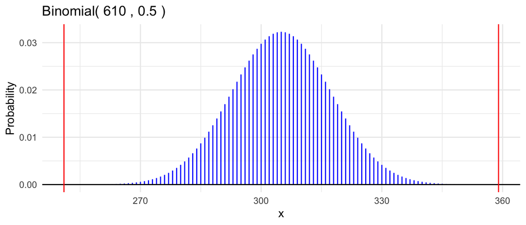

```r
null_p = 0.5

gbinom(610, null_p, scale = TRUE) +
  geom_vline(xintercept = 359, color = "red") +
  geom_vline(xintercept = 251, color = "red")
```

> p-value:

```r
(1 - pbinom(358, 610, 0.5))*2
```

```
## [1] 1.405895e-05
```

#### 8

The previous statistical inferences assume a binomial model for the observed number of prosocial choices for trials with and without a partner.

State one criticism where reality may differ from the assumptions, potentially leading to misleading conclusions. (What is an example of an assumption of the binomial model which, in the given context, is questionable?)

> There are numerous things that can affect this experiment. First we assume that all trials are independent, but actually they might be dependent in real life. Monkeys have some intelligence to do reasonable choices. Than depending on the character of the monkey it would make a prosocial choice or no. Also we assume that the monkeys cannt communicate, but they can do some primitive gestures which are a type of communication.

> Depending on whether the experiment is done with monkey 1 and 2, and after 2 and 3, and after 3 and 4, and so on.. or monkey 1 and 2, and after 3 and 4, and after 5 and 6, and so on.. In the first case the monkey 2 will know what hapens and will know how to behave when they put in with monkey 3, where as in the second case we take new monkeys every time we experiment.

> One more assumption is that the identities of the chimpanzees and their partners do not affect the prosocial trial probabilities, which could be questionable in different life. If we do an experiment with a mother and a child - they will allways share.

> Overall, the assumption that all trials are independent is questionable (assumption made in q6).